# Statistical Modelling II

Mauricio Garcia Tec

$$\DeclareMathOperator{\N}{N}
\DeclareMathOperator{\Gam}{Gamma}
\DeclareMathOperator{\Wish}{Wishart}
\DeclareMathOperator{\tr}{tr}$$

[Return to main Index](https://github.com/mauriciogtec/statsmodelling2)

# Section 2: Bayesian inference Gaussian modelS

## Bayesian inference in a simple Gaussian model

Let’s start with a simple, one-dimensional Gaussian example, where

$$y_i |\mu, \sigma^2 \sim \N(\mu,\sigma^2).$$

We will assume that $\mu$ and $\sigma$ are unknown, and will put conjugate priors on them both, so that
$$\begin{aligned}
\sigma^2 \sim& \mbox{Inv-Gamma}(\alpha_0, \beta_0)\\
\mu|\sigma^2 \sim& \mbox{Normal}\left(\mu_0, \frac{\sigma^2}{\kappa_0}\right)
\end{aligned}$$

or, equivalently,
$$\begin{aligned}
y_i |\mu, \omega \sim& \mbox{N}(\mu,1/\omega)\\
\omega \sim& \mbox{Gamma}(\alpha_0, \beta_0)\\
\mu|\omega \sim& \mbox{Normal}\left(\mu_0, \frac{1}{\omega\kappa_0}\right)
\end{aligned}$$
We refer to this as a normal/inverse gamma prior on $\mu$ and $\sigma^2$ (or a normal/gamma prior on $\mu$ and $\omega$). We will now explore the posterior distributions on $\mu$ and $\omega$– much of this will involve similar results to those obtained in the first set of exercises.

### Exercise 1

*Derive the conditional posterior distributions $p(\mu, \omega|y_1,\dots, y_n)$ and show that it is in the same family as $p(\mu, \omega)$. What are the updated parameters $\alpha_n, \beta_n,\mu_n$ and $\kappa_n$?*

*Solution 1*. I will parametrise the Normal distribution throughout using precisions only. The prior for $(\mu, \omega)$ is known as the $\mathrm{NormalGamma}(\mu_0,\kappa_0, \alpha_0,\beta_0)$ prior and it has functional form
$$\begin{aligned}
p(\mu,\omega) & \propto \N(\mu \mid \mu_0, \kappa_0\omega)\Gam(\omega \mid \alpha_0,\beta_0) \\
& \propto \omega^{\alpha_0 - 1/2}\exp\left\{-\frac{\kappa_0\omega}{2}(\mu - \mu_0)^2\right\}\exp\left\{-\beta_0\omega\right\} \\
\end{aligned}$$
The posterior is
$$\begin{aligned}
p(\mu,\omega \mid y) & \propto p(\mu,\omega)p(y\mid \mu,\omega) \\
& \propto \omega^{\alpha_0 + n/2 - 1/2}\exp\left\{-\frac{\kappa_0\omega}{2}(\mu - \mu_0)^2\right\}\exp\left\{-\beta_0\omega\right\}\\
& \quad \times \exp\left\{-\frac{\omega}{2}\sum_i(y_i - \mu)^2\right\} \\
& \propto \omega^{\alpha_0 + n/2 - 1/2}\exp\left\{-\frac{\kappa_0\omega}{2}(\mu - \mu_0)^2\right\}\exp\left\{-\beta_0\omega\right\} \\
& \quad \times \exp\left\{-\frac{\omega}{2}\left[\sum_i(y_i - \bar{y})^2+ n(\mu - \bar{y})^2\right]\right\} \\
& \propto \omega^{\alpha_0 + n/2 - 1/2}\exp\left\{-\omega\left(\beta_0 + \frac{1}{2}\sum_i(y_i - \bar{y})^2 + \frac{\kappa_0n}{2(\kappa_0 + n)}(\mu_0 - \bar{y})^2\right)\right\} \\
& \quad \times \exp\left\{-\frac{(n + \kappa_0)\omega}{2}\left(\mu - \left(\frac{n}{n + \kappa_0}\bar{y} + \frac{\kappa_0}{n + \kappa_0}\mu_0\right)\right)^2\right\} \\
& \propto \mathrm{NormalGamma}(\mu_n, \kappa_n, \alpha_n, \beta_n).
\end{aligned}$$

where
$$\mu_n = \frac{n}{n + \kappa_0}\bar{y} + \frac{\kappa_0}{n + \kappa_0}\mu_0, \quad \kappa_n = n + \kappa_0, \\
\alpha_n = \alpha_0 + n/2, \quad \text{and} \quad\beta_n = \beta_0 + \frac{1}{2}\sum_i(y_i - \bar{y})^2 + \frac{\kappa_0n}{2(\kappa_0 + n)}(\mu_0 - \bar{y})^2$$

Back to Index

### Exercise 2

*Derive the conditional posterior distribution $p(\mu|\omega,y_1,\dots, y_n)$ and $p(\omega|y_1,\dots, y_n)$. Based on this and the previous exercise, what are reasonable interpretations for the parameters $\mu_0,\kappa_0, \alpha_0$ and $\beta_0$?*

*Solution 2*. From the functional form it is evident that $(\mu \mid \omega, y) \sim \N(\mu_n, \kappa_n\omega)$ and $(\omega \mid y) \sim \Gam(\alpha_n, \beta_n)$. We interpret $\mu_0$ as first-guess for the mean, $\kappa_0$ as pseudo-counts, $\beta_0$ as a pseudo sum of squared errors, and $\alpha_0$ also as a pseudo count also (related to the degrees of freedom of the error).

Back to Index

### Exercise 3

Show that the marginal distribution over $\mu$ is a centered, scaled $t$-distribution (note we showed something very similar in the last set of exercises!), i.e.
$$p(\mu) \propto \left(1+\frac{1}{\nu}\frac{(\mu-m)^2}{s^2}\right)^{-\frac{\nu+1}{2}}$$
What are the location parameter $m$, scale parameter $s$, and degree of freedom $\nu$?

*Solution 3*. We integrate
$$\begin{aligned}
p(\mu) & = \int p(\mu, \omega) d\omega \\
& \propto \int \omega^{\alpha_0 - 1/2}\exp\left\{-\beta_0\omega - \frac{\kappa_0\omega}{2}(\mu - \mu_0)^2\right\} d\omega \\
& \propto \left(\beta_0 + \frac{1}{2}(\mu - \mu_0)^2\right)^{-(\alpha_0 + 1/2)} \\
& \propto \left(1 + \frac{1}{2\alpha_0}\frac{ \kappa_0(\mu - \mu_0)^2}{\beta_0/\alpha_0}\right)^{-(2\alpha_0 + 1)/2} \\
& \propto \mathrm{tStudent}(\mu \mid \mu_0, \kappa_0\beta_0/\alpha_0, 2\alpha_0).
\end{aligned}$$
Thus, the marginal prior of $\mu$ is tStudent centered at $\mu_0$, with dispersion $\beta_n/(\kappa_0\alpha_n)$, and $2\alpha_0$ degrees of freedom.

Back to Index

### Exercise 4

*The marginal posterior $p(\mu|y_1,\dots, y_n)$ is also a centered, scaled $t$-distribution. Find the updated location, scale and degrees of freedom.*

*Solution 4*. The development is identical to the previous case, allowing us to conclude
$$p(\mu \mid y) = \mathrm{tStudent}(\mu \mid \mu_n,\beta_n/(\kappa_0\alpha_n), 2\alpha_n).$$

Back to Index

### Exercise 5

*Derive the posterior predictive distribution $p(y_{n+1},\dots, y_{n+m} \mid y_1,\dots, y_{m})$.*

*Solution 5*. We need to integrate over the posterior
$$\begin{aligned}
p(y_* \mid y) &= \int\!\!\!\int p(y_* \mid \mu, \omega)p(\mu, \omega \mid y)d\mu d\omega \\
& \propto \int \omega^{\alpha_n}\exp\left\{-\beta_n\omega\right\} \int\exp\left\{-\frac{\omega}{2}\left((\mu - y_*)^2 + \kappa_n(\mu - \mu_n)^2\right)\right\} d\mu d\omega \\
& \propto \int \omega^{\alpha_n}\exp\left\{-\omega\left(\beta_n + \frac{\kappa_n}{2(1 + \kappa_n)}(y_* - \mu_n)^2 \right)\right\} \\
& \quad\quad \times \left[\int\exp\left\{-\frac{\omega(1 + \kappa_n)}{2}\left((\mu - \frac{y_* + \kappa_n\mu_n}{1 + \kappa_n}\right)^2\right\} d\mu \right] d\omega \\
& \propto \int \omega^{\alpha_n - 1/2}\exp\left\{-\omega\left(\beta_n + \frac{\kappa_n}{2(1 + \kappa_n)}(y_* - \mu_n)^2 \right)\right\} d\omega \\
& = \left(\beta_n + \frac{\kappa_n}{2(1 + \kappa_n)}(y_* - \mu_n)^2 \right)^{-(2\alpha_n + 1)/2} \\
& \propto \left(1 + \frac{1}{2\alpha_n}\frac{(y_* - \mu_n)^2}{(1 + 1/\kappa_n)\beta_n/\alpha_n} \right)^{-(2\alpha_n + 1)/2} \\
& \propto \mathrm{tStudent}\left(y_* \mid \mu_n, \left(1 + 1/\kappa_n\right)\beta_n / \alpha_n, 2\alpha_n\right).
\end{aligned}$$
Interestingly, the new value $y_*$ has an additional dispersion of a factor $1 + 1/\kappa_n$ with respect to the posterior mean.

We can extend this to more variables. The interesting thing is that they will not longer be independent! They will still be uncorrelated, but they will be jointly distributed as a multivariate tStudent.
$$\begin{aligned}
p(y_{*,1},..., y_{*,m} \mid y) & \propto \left(1 + \frac{1}{2\alpha_n}\frac{1}{(1 + 1/\kappa_n)\beta_n/\alpha_n}\sum_{i=1}^m(y_{*,i} - \mu_n)^2 \right)^{-(2\alpha_n + m)/2} \\
& \propto \mathrm{tStudent}\left(y_{*,1},..., y_{*,m} \mid \mu_n\underline{1}_m, \left(1 + 1/\kappa_n\right)(\beta_n / \alpha_n) I_m, 2\alpha_n\right)
\end{aligned}$$
where $I_m$ is the identity matrix of size $m$ and $\underline{1}_m$ is the vector of ones of size $m$.

Back to Index

### Exercise 6

*Derive the marginal distribution over $y_1,\dots, y_n$.*

*Solution 6*. This is completely analogous to the previous but we are using the prior instead of the posterior. This is also known as prior predtictive. Since the prior and posterior have the same functional form we see that
$$\begin{aligned}
p(y_1,...,y_n) &= \int\!\!\!\int p(y_1,...,y_n \mid \mu, \omega)p(\mu, \omega)d\mu d\omega \\
& \propto \mathrm{tStudent}\left(y_1,...,y_n \mid \mu_0\underline{1}_n, \left(1 + 1/\kappa_0\right)(\beta_0 / \alpha_0) I_n, 2\alpha_0\right)
\end{aligned}$$

Back to Index

## Bayesian inference in a multivariate Gaussian model

Let’s now assume that each $y_i$ is a $d$-dimensional vector, such that

$$y_i \sim \mbox{N}(\mu, \Sigma)$$
for $d$-dimensional mean vector $\mu$ and $d\times d$ covariance matrix $\Sigma$.

We will put an *inverse Wishart* prior on $\Sigma$. The inverse Wishart distribution is a distribution over positive-definite matrices parametrized by $\nu_0>d-1$ degrees of freedom and positive definite matrix $\Lambda_0^{-1}$, with pdf

$$p(\Sigma\mid \nu_0, \Sigma_0^{-1}) = \frac{|\Sigma_0|^{\nu_0/2}}{2^{d\nu_0/2}\Gamma_d(\nu_0/2)}|\Sigma|^{-\frac{\nu_0+d+1}{2}}e^{-\frac{1}{2}\mbox{tr}(\Sigma_0\Sigma^{-1})} \propto |\Sigma|^{-\frac{\nu_0+d+1}{2}}e^{-\frac{1}{2}\tr(\Sigma_0\Sigma^{-1})}.$$
where $\Gamma_d(x) = \pi^{d(d-1)/4}\prod_{i=1}^d\Gamma\left(x-\frac{j-1}{2}\right)$.

We can also work with the precision matrix $\Lambda = \Sigma^{-1}$ instead; $\Lambda$ follows a *Wishart distribution* id
$$p(\Lambda \mid \nu_0, \Lambda_0) = \frac{|\Lambda_0|^{-\nu_0/2}}{2^{d\nu_0/2}\Gamma_d(\frac{}{}\nu_0/2)}\Lambda^{\frac{\nu_0 - d - 1}{2}} e^{-\frac{1}{2}\Lambda_0^{-1}\Lambda} \propto \Lambda^{\frac{\nu_0 - d - 1}{2}} e^{-\frac{1}{2}\tr(\Lambda_0^{-1}\Lambda)}$$
It is worth noticing that $E[\Lambda] = \nu_0\Lambda_0$. We can choose reasonable prior by thinking of $\Omega_0 = \Lambda_0^{-1}$ as a prior sum of squared errors and $\nu_0$ as the degrees of freedom. So that $E[\Lambda] = 1 / \text{mse}_0$.

### Exercise 7

*Show that in the univariate case, the inverse Wishart distribution reduces to the inverse gamma distribution.*

*Solution 7*. I’ll show the Wishart reduces to Gamma. If $d=1$ and $\lambda \sim \Wish(\nu_0, \lambda_0)$ then by definition (the trace of a scalar is the scalar itself)
$$\Wish(\lambda \mid \nu_0, \lambda_0)\propto \lambda^{\nu_0/2 - 1}e^{-\frac{1}{2}\lambda / \lambda_0} = \Gam(\lambda \mid \nu_0/2, \lambda_0^{-1}).$$
So the rate of the Gamma is given by $1 / \lambda_0$ (alternatively, $\lambda_0$ is the scale), and $\nu_0$ is the shape.

Back to Index

### Exercise 8

Let $\Sigma \sim \mbox{Inv-Wishart}(\nu_0, \Omega_0^{-1})$ and $\mu|\Sigma \sim \mbox{N}(\mu_0, \Sigma/\kappa_0)$, so that
$$p(\mu,\Sigma) \propto |\Sigma|^{-\frac{\nu_0+d+2}{2}}e^{-\frac{1}{2}\mbox{tr}(\Omega_0\Sigma^{-1}) - \frac{\kappa_0}{2}(\mu-\mu_0)^T\Sigma^{-1}(\mu-\mu_0)}$$
and let
$$y_i \sim \mbox{N}(\mu, \Sigma)$$
. Show that $p(\mu, \Sigma|y_1,\dots,y_n)$ is also normal-inverse Wishart distributed, and give the form of the updated parameters $\mu_n, \kappa_n, \nu_n$ and $\Lambda_n$.

*Solution 8*. Working with precisions instead, we’ll say $(\mu, \Lambda) \sim \mathrm{NormalWishart}(\mu_0, \kappa_0, \nu_0, \Lambda_0)$ if
$$p(\mu, \Lambda) \propto |\Lambda|^{-\frac{\nu_0 - d }{2}} \exp\left\{-\frac{1}{2}\left\lVert\Lambda^{1/2}(\mu-\mu_0)\right\rVert^2\right\} \exp\left\{-\frac{1}{2}\tr(\Lambda_0^{-1}\Lambda)\right\}$$
It will look extremely nasty but most of the proof is analogous to the univariate case. Define $\kappa_n = \kappa_0 + n$ and $\mu_n = (n\bar{y} + \kappa_0)/(n + \kappa_0)$ as before. Then
$$\begin{aligned}
p(\mu,\omega \mid y) & \propto p(\mu,\omega)p(y\mid \mu,\omega) \\
& \propto |\Lambda|^{\frac{\nu_0 + n - d }{2}} \exp\left\{-\frac{\kappa_0}{2}\left\lVert\Lambda^{1/2}(\mu-\mu_0)\right\rVert^2\right\}\exp\left\{-\frac{1}{2}\tr(\Lambda_0^{-1}\Lambda)\right\} \\
& \quad \times \exp\left\{-\frac{1}{2}\sum_i\left\lVert\Lambda^{1/2}(y_i -\mu)\right\rVert^2\right\} \\
& \propto |\Lambda|^{\frac{\nu_0 + n - d }{2}}\exp\left\{-\frac{\kappa_0}{2}\left\lVert\Lambda^{1/2}(\mu-\mu_0)\right\rVert^2\right\}\exp\left\{-\frac{1}{2}\tr(\Lambda_0^{-1}\Lambda)\right\}\\
& \quad \times \exp\left\{-\frac{1}{2}\left[\sum_i\left\lVert\Lambda^{1/2}(y_i -\bar{y})\right\rVert^2 + n\left\lVert\Lambda^{1/2}(\mu - \bar{y})\right\rVert^2\right]\right\} \\
& \propto |\Lambda|^{\frac{\nu_0 + n - d }{2}}\exp\left\{-\frac{1}{2}\sum_i\left\lVert\Lambda^{1/2}(y_i - \bar{y})\right\rVert^2 - \frac{n\kappa_0}{2\kappa_n}\left\lVert\Lambda^{1/2}(\bar{y} -\mu_0)\right\rVert^2\right\} \\
& \quad \times \exp\left\{-\frac{1}{2}\tr(\Lambda_0^{-1}\Lambda)\right\}\exp\left\{-\frac{\kappa_n}{2}\left\lVert\Lambda^{1/2}(\mu -\mu_n)\right\rVert^2 \right\}\\
& \propto |\Lambda|^{\frac{\nu_0 + n - d }{2}}\exp\left\{-\frac{1}{2}\tr\left(\sum_i(y_i - \bar{y})(y_i - \bar{y})^\top\Lambda\right) - \frac{n\kappa_0}{2\kappa_n}\tr\left((\mu_0 - \bar{y})(\mu_0 - \bar{y})^\top\Lambda\right)\right\} \\
& \quad \times \exp\left\{-\frac{1}{2}\tr(\Lambda_0^{-1}\Lambda)\right\}\exp\left\{-\frac{\kappa_n}{2}\left\lVert\Lambda^{1/2}(\mu -\mu_n)\right\rVert^2 \right\}\\
& \propto |\Lambda|^{\frac{\nu_0 + n - d }{2}} \exp\left\{-\frac{\kappa_n}{2}\left\lVert\Lambda^{1/2}(\mu -\mu_n)\right\rVert^2 \right\}\\
& \quad \times \exp\left\{-\frac{1}{2}\tr\left(\left(\Lambda_0^{-1} + \sum_i(y_i - \bar{y})(y_i - \bar{y})^\top + \frac{n\kappa_0}{\kappa_n}(\mu_0 - \bar{y})(\mu_0 - \bar{y})^\top\right)\Lambda\right)\right\} \\
& \propto \mathrm{NormalWishart}(\mu_n, \kappa_n, \nu_n, \Lambda_n).
\end{aligned}$$
where $\mu_n$ and $\kappa_n$ where defined before (same as NormalGamma case) and
$$\nu_n = \nu_0 + n,\quad \text{ and } \quad \Lambda_n^{-1} = \Lambda_0^{-1} + \sum_i(y_i - \bar{y})(y_i - \bar{y})^\top + \frac{n\kappa_0}{\kappa_n}(\mu_0 - \bar{y})(\mu_0 - \bar{y})^\top$$

Back to Index

## A Gaussian linear model

Lets now add in covariates, so that

$$\mathbf{y}|\beta, X \sim \mbox{Normal}(X\beta, (\omega \Lambda)^{-1})$$

where $\mathbf{y}$ is a vector of $n$ responses; $X$ is a $n\times d$ matrix of covariates; and $\Lambda$ is a known positive definite matrix. Let’s assume $\beta\sim \mbox{Normal}(\mu, (\omega K)^{-1})$ and $\omega \sim \mbox{Gamma}(a,b)$, where $K$ is assumed fixed.

**NOTE: For this exercise I will only consider the case when $\Lambda$ is the identity matrix. The justification is that by defining $\tilde{X} = \Lambda^{1/2}X$ and $\tilde{y} = \Lambda^{1/2}y$ then our model becomes $(\tilde{y} \mid \tilde{X}, \beta) \sim \N(\tilde{X}\beta, \omega I_n)$. We’ll drop the tilde’s from the notation. We’ll also denote the prior parameters with underscript naught to emphasise the updating process (and analogy with the case without covariates)**

### Exercise 9

*Derive the conditional posterior $p(\beta \mid \omega, y_1,...,y_n)$*

*Solution 9*. Direct computation
$$\begin{aligned}
p(\beta \mid \omega, y) & \propto p(y \mid \beta, \omega) p(\beta \mid \omega)\\
& \propto \exp\left\{-\frac{\omega}{2}\lVert y - X\beta \rVert^2\right\}\exp\left\{-\frac{\omega}{2}\lVert K_0^{1/2}(\beta - \mu_0)\rVert^2\right\} \\
& \propto \exp\left\{-\frac{\omega}{2}\lVert K_n^{1/2}(\beta - \mu_n)\rVert^2\right\} \\
& \propto \N(\beta \mid \mu_n, \omega K_n)
\end{aligned}$$
where $K_n = X'X + K_0$ and
$$\mu_n = K_n^{-1}\left((X'X)\hat{y} + K_0\mu_0\right) = K_n^{-1}(X'y + K_0\mu_0).$$
In the formula above, $\hat{y}$ is the solution to the least squares problem (which satisfies $(X'X)\hat{y} = X'y)$. As in the previous case, the posterior mean appears as a weighted sum of the least squares estimator and the prior mean $\mu_0$. Another intuition driving this is that we recover the case without covariates with $X$ as the vector of ones. So $X'X = n$; this in part explains why the formulas should have $n$ replace with $X'X$.

Back to Index

### Exercise 10

*Derive the marginal posterior $p(\omega \mid y_1,\dots, y_n)$.*

*Solution 10*. Direct computation
$$\begin{aligned}
p(\omega \mid y) & = \int p(\omega, \beta \mid y) d\beta \\
& \propto \int p(y \mid \beta, \omega)p(\beta \mid \omega)p(\omega) d\beta \\
& \propto \omega^{n/2 + a_0 - 1/2} \exp\left\{-\omega \left(b_0 + \frac{1}{2}\left[y'y + \mu_0K_0\mu_0 - \mu_n K_n\mu_n\right]\right)\right\} \\
& \quad\quad \times \int \exp\left\{-\frac{\omega}{2}\lVert K_n^{1/2}(\beta - \mu_n)\rVert^2\right\} d\beta \\
& \propto \omega^{n/2 + a_0 - 1} \exp\left\{-\omega \left(b_0 + \frac{1}{2}\left[y'y + \mu_0K_0\mu_0 - \mu_n K_n\mu_n\right]\right)\right\}\\
& = \omega^{n/2 + a_0 - 1} \exp\left\{-\omega \left(b_0 + \frac{1}{2}\left(\lVert y - X\mu_n\rVert^2 + \lVert K_0^{1/2}(\mu_n - \mu_0) \rVert^2 \right)\right)\right\}\\
& = \omega^{a_n - 1} \exp\left\{-\omega\beta_n\right\}\\
& \propto \Gam(a_n, b_n)
\end{aligned}$$
where $a_n = a + n/2$ and $b_n =b_0 + \frac{1}{2}\left(\lVert y - X\mu_n\rVert^2 + \lVert K_0^{1/2}(\mu_n - \mu_0) \rVert^2 \right)$. We again can interpret $a_n$ as degrees of freedom and $b_n$ as sum of squared errors with a penalization for the prior guess.

Back to Index

### Exercise 11

*Derive the marginal posterior $p(\beta \mid y_1,\dots, y_n)$.*

*Solution 11*. Direct computation
$$\begin{aligned}
p(\beta \mid y) & = \int p(\beta, \omega \mid y) d\omega \\
& \propto \int \omega^{a_n - 1/2} \exp\left\{-\omega\beta_n\right\} \exp\left\{-\frac{\omega}{2}\lVert K_n^{1/2}(\beta - \mu_n)\rVert^2\right\} d\omega \\
& = \int \omega^{a_n - 1/2} \exp\left\{-\omega\left(\beta_n + \frac{1}{2}\lVert K_n^{1/2}(\beta - \mu_n)\rVert^2\right)\right\} d\omega \\
& \propto \left(\beta_n + \frac{1}{2}\lVert K_n^{1/2}(\beta - \mu_n)\rVert^2\right)^{-\frac{2\alpha_n + 1}{2}} \\
& \propto \left(1 + \frac{1}{2\alpha_n}\frac{\lVert K_n^{1/2}(\beta - \mu_n)\rVert^2}{\beta_n/\alpha_n}\right)^{-\frac{2\alpha_n + 1}{2}} \\
& \propto \mathrm{tStudent}\left(\beta \mid \mu_n ,\; (\beta_n/\alpha_n)K_n^{-1},\; 2\alpha_n \right).
\end{aligned}$$
We arrive to a tStudent distribution with mean $\mu_n$, dispersion $(\beta_n/\alpha_n)K_n^{-1}$ and $2\alpha_n$ degrees of freedom.

Back to Index

### Exercise 12

*Download the dataset dental.csv from Github. This dataset measures a dental distance (specifically, the distance between the center of the pituitary to the pterygomaxillary fissure) in 27 children. Add a column of ones to correspond to the intercept. Fit the above Bayesian model to the dataset, using $\Lambda=I$ and $K=I$, and picking vague priors for the hyperparameters, and plot the resulting fit. How does it compare to the frequentist LS and ridge regression results?*

*Solution 12*.

```r
library(tidyverse)
library(mvtnorm)
library(Matrix)
```

Read the data

```r
dental <- read_csv("dental.csv")[ ,-1] %>%
  mutate(female = as.integer(Sex == 'Female'))
head(dental)
```

| distance | age | Subject | Sex | female |
| --- | --- | --- | --- | --- |
| 26.0 | 8 | M01 | Male | 0 |
| 25.0 | 10 | M01 | Male | 0 |
| 29.0 | 12 | M01 | Male | 0 |
| 31.0 | 14 | M01 | Male | 0 |
| 21.5 | 8 | M02 | Male | 0 |
| 22.5 | 10 | M02 | Male | 0 |

```r
X <- dental %>%
  model.matrix(~ age + female, data = .)
y <- dental$distance
head(X)
```

```
  (Intercept) age female
1           1   8      0
2           1  10      0
3           1  12      0
4           1  14      0
5           1   8      0
6           1  10      0
```

```r
gibbs_sampler12 <- function(nsim, X, y, prior) {
  # metadata
  n <- nrow(X)
  d <- ncol(X)

  # initialise
  beta <- matrix(0, nsim, d)
  omega <- numeric(nsim)

  # computed quantities
  Kn <- crossprod(X) + prior$K0
  Kn_inv <- solve(Kn)
  mn <- solve(Kn, crossprod(X, y) + prior$K0 %*% prior$m0)
  an <- prior$a0 + n/2
  bn <- prior$b0 + 0.5*drop(crossprod(y - X %*% mn)) +
    0.5*drop(crossprod(mn - prior$m0, prior$K0 %*% (mn - prior$m0)))

  # sampler
  for (k in 1:nsim) {
    omega[k] <- rgamma(1, shape = an, rate = bn)
    beta[k, ] <- rmvnorm(1, mean = mn, sigma = as(Kn_inv / omega[k], "matrix"))
  }

  params <- data.frame(cbind(beta, omega))
  names(params) <- c(colnames(X), "omega")
  params
}
```

Now let’s test it

```r
# Create prior
d <- ncol(X)
prior <- list(m0 = numeric(d), K0 = Diagonal(d), a0 = 1, b0 = 10)
# Run the sampler
nsim <- 1000
set.seed(999)
params <- gibbs_sampler12(nsim, X, y, prior)
```

Let’s plot and print some results

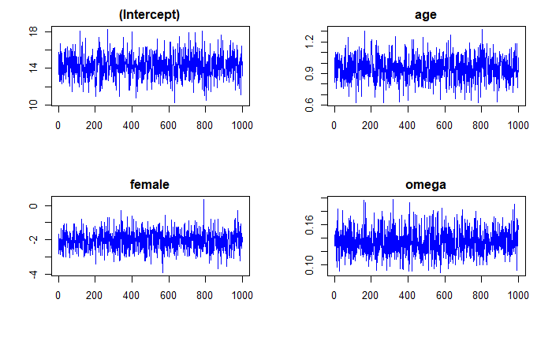

```r
par(mfrow = c(2, 2))
for (j in 1:4) {
  plot(params[ ,j],
       type = "l", col = "blue",
       main = names(params)[j],
       xlab = "", ylab = "")
}
```

Let’s now see the distribution of the parameters

```r
describe <- function(x) {
  data_frame(mean = mean(x), sd = sd(x), low95 = quantile(x, 0.025), up95 = quantile(x, 0.975))
}
params %>%
  mutate(sd = 1 / sqrt(omega)) %>%
  map(describe) %>%
  bind_rows() %>%
  add_column(variable = c(names(params), "std.dev"), .before = 1)
```

| variable | mean | sd | low95 | up95 |
| --- | --- | --- | --- | --- |
| (Intercept) | 14.2816731 | 1.22616105 | 11.7293452 | 16.7300663 |
| age | 0.9483100 | 0.10962399 | 0.7340803 | 1.1711017 |
| female | -2.0341898 | 0.54347222 | -3.0330237 | -0.9665265 |
| omega | 0.1341869 | 0.01864054 | 0.1000578 | 0.1731728 |
| std.dev | 2.7496790 | 0.19176549 | 2.4030360 | 3.1613647 |

Now let’s compare with the Ridge regression coefficients. As expected these coincide with our Bayesian model.

```r
ridge <- drop(solve(crossprod(X) + Diagonal(d) * prior$K0, crossprod(X, y)))
ridge
```

```
(Intercept)         age      female
 14.2732038   0.9491779  -2.0205127
```

```r
ols <- drop(solve(crossprod(X), crossprod(X, y)))
ols
```

```
(Intercept)         age      female
 17.7067130   0.6601852  -2.3210227
```

Back to Index

## A hierarchical Gaussian linear model

The dental dataset has heavier tailed residuals than we would expect under a Gaussian model. We’ve seen previously that we can model a scaled $t$-distribution using a scale mixture of Gaussians; let’s put that into effect here. Concretely, let
$$\begin{aligned}
\mathbf{y}|\beta,\omega,\Lambda \sim& \mbox{N}(X\beta, (\omega \Lambda)^{-1})\\
\Lambda =& \mbox{diag}(\lambda_1,\dots, \lambda_n)\\
\lambda_i \stackrel{\small{iid}}{\sim} \mbox{Gamma}(\tau,\tau)\\
\beta|\omega \sim& \mbox{N}(\mu, (\omega K)^{-1})\\
\omega \sim& \mbox{Gamma}(a,b)
\end{aligned}$$

### Exercise 13

*What is the conditional posterior, $p(\lambda_i|\mathbf{y},\beta, \omega)$?*

*Solution 13*. Easy computation
$$\begin{aligned}
p(\lambda_i \mid \beta, \omega, y) & \propto p(y_i \mid \beta, \omega, \lambda_i) p(\lambda_i) \\
& \propto \lambda_i^{\tau - 1/2}\exp\left\{-\tau - \frac{\omega\lambda_i}{2}(y_i - x_i'\beta)^2\right\} \\
& \propto \Gam\left(\lambda_i \mid \tau + 1/2, \tau + \frac{\omega}{2}(y_i - x_i'\beta)^2\right)
\end{aligned}$$

Back to Index

### Exercise 14

*Write a Gibbs sampler that alternates between sampling from the conditional posteriors of $\lambda_i$, $\beta$ and $\omega$, and run it for a couple of thousand samplers to fit the model to the dental dataset.*

*Solution 14*

```r
library(tidyverse)
library(mvtnorm)
library(Matrix)
library(ggplot2)
```

```r
gibbs_sampler14 <- function(nsim, X, y, prior) {
  # metadata
  n <- nrow(X)
  d <- ncol(X)

  # initialise
  beta <- matrix(0, nsim, d)
  omega <- numeric(nsim)
  lambda <- matrix(0, nsim + 1, n)
  lambda[1, ] <- 1
  # sampler
  for (k in 1:nsim) {
    Kn <- crossprod(X, lambda[k, ]*X) + prior$K0
    Kn_inv <- solve(Kn)
    mn <- solve(Kn, crossprod(X, lambda[k, ]*y) + prior$K0 %*% prior$m0)
    err <- as.numeric(y - X %*% mn)
    an <- prior$a0 + n/2
    bn <- prior$b0 + 0.5*drop(crossprod(err, lambda[k, ] * err)) +
      0.5*drop(crossprod(mn - prior$m0, prior$K0 %*% (mn - prior$m0)))
    taun <- prior$tau + 0.5*omega[k] * err^2
    omega[k] <- rgamma(1, shape = an, rate = bn)
    beta[k, ] <- rmvnorm(1, mean = mn, sigma = as(Kn_inv / omega[k], "matrix"))
    lambda[k + 1, ] <- map_dbl(taun, ~ rgamma(1, prior$tau + 0.5, .))
  }
  lambda <- lambda[-1, ]

  list(beta = beta, omega = omega, lambda = lambda)
}
```

```r
# Create prior
d <- ncol(X)
prior <- list(m0 = numeric(d), K0 = Diagonal(d), a0 = 1, b0 = 10, tau = 1)
# Run the sampler
nsim <- 1000
set.seed(999)
res14 <- gibbs_sampler14(nsim, X, y, prior)
```

Let’s see the distribution of the coefficients. We see some change with respect to the previous model.

```r
beta <- data.frame(res14$beta)
beta %>%
  map(describe) %>%
  bind_rows() %>%
  add_column(variable = colnames(X), .before = 1)
```

| variable | mean | sd | low95 | up95 |
| --- | --- | --- | --- | --- |
| (Intercept) | 15.1467583 | 1.4029869 | 12.4247504 | 17.830619 |
| age | 0.8757886 | 0.1229503 | 0.6334509 | 1.115796 |
| female | -2.0992931 | 0.5931932 | -3.2833673 | -0.984465 |

Let’s see if the uncertainty correlates with some of the covariates

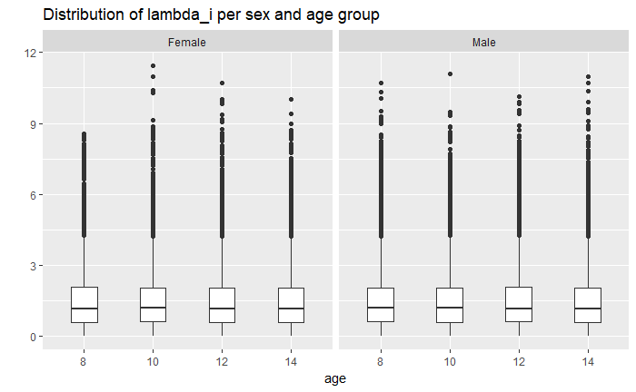

```r
pltdata <- data.frame(lambda = t(res14$lambda), age = ordered(dental$age), sex = dental$Sex)
pltdata <- pltdata %>%
  gather(subject, lambda, -c(age, sex))
ggplot(pltdata, aes(age, lambda)) +
  geom_boxplot() +
  facet_grid(. ~ sex) +
  ylab("") +
  ggtitle(paste("Distribution of", expression(lambda_i), "per sex and age group"))
```

Now let’s look at the residuals

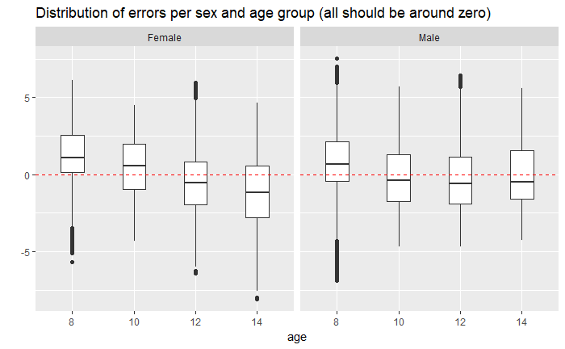

```r
beta <- t(res14$beta)
err <- y - X %*% beta
pltdata <- data.frame(mean_err = err, age = ordered(dental$age), sex = dental$Sex)
pltdata <- pltdata %>%
  gather(subject, error, -c(age, sex))
ggplot(pltdata, aes(age, error)) +
  geom_boxplot() +
  geom_hline(aes(yintercept = 0), colour = "red", linetype = "dashed") +
  facet_grid(. ~ sex) +
  ylab("") +
  ggtitle(paste("Distribution of errors per sex and age group (all should be around zero)"))
```

The evidence suggests an interaction effect between age and sex, which we shall try to resolve in exercise 15.

Back to Index

### Exercise 15

- Compare the two fits. Does the new fit capture everything we would like? What assumptions is it making? In particular, look at the fit for just male and just female subjects. Suggest ways in which we could modify the model, and for at least one of the suggestions, write an updated Gibbs sampler and run it on your model.*

*Solution 15*. I first want to rerun the regression but with an interaction term, and see what happens to the errors. Also I will treat age as a categorical instead of numerical variable (since it has only four values).

```r
X2 <- dental %>%
  mutate(age = factor(age)) %>%
  model.matrix(~ age + female + female*age, data = .)
y <- dental$distance
head(X2)
```

```
  (Intercept) age10 age12 age14 female age10:female age12:female age14:female
1           1     0     0     0      0            0            0            0
2           1     1     0     0      0            0            0            0
3           1     0     1     0      0            0            0            0
4           1     0     0     1      0            0            0            0
5           1     0     0     0      0            0            0            0
6           1     1     0     0      0            0            0            0
```

```r
# Create prior
d <- ncol(X2)
prior <- list(m0 = numeric(d), K0 = Diagonal(d), a0 = 1, b0 = 10, tau = 1)
# Run the sampler
nsim <- 1000
set.seed(999)
res15 <- gibbs_sampler14(nsim, X2, y, prior)
```

```r
beta <- data.frame(res15$beta)
beta %>%
  map(describe) %>%  # describe was defined in question 12
  bind_rows() %>%
  add_column(variable = colnames(X2), .before = 1)
```

| variable | mean | sd | low95 | up95 |
| --- | --- | --- | --- | --- |
| (Intercept) | 22.3726042 | 0.7509012 | 20.9892453 | 23.8150335 |
| age10 | 1.4043825 | 1.0759836 | -0.7004824 | 3.4914866 |
| age12 | 3.1493356 | 1.0718926 | 1.1275016 | 5.2507344 |
| age14 | 4.8126858 | 1.0178261 | 2.8738719 | 6.7579590 |
| female | -1.2749333 | 1.0973847 | -3.3661713 | 0.8306791 |
| age10:female | -0.2358149 | 1.5610276 | -3.3216736 | 2.8863379 |
| age12:female | -1.0423907 | 1.5859290 | -4.0420197 | 2.1402182 |
| age14:female | -1.6957841 | 1.5429538 | -4.9074610 | 1.0785443 |

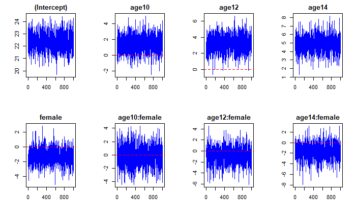

```r
par(mfrow = c(2, 4))
for (j in 1:ncol(beta)) {
  plot(beta[ ,j],
       type = "l", col = "blue",
       main = colnames(X2)[j],
       xlab = "", ylab = "")
  abline(h=0, col = "red", lt = 2)
}
```

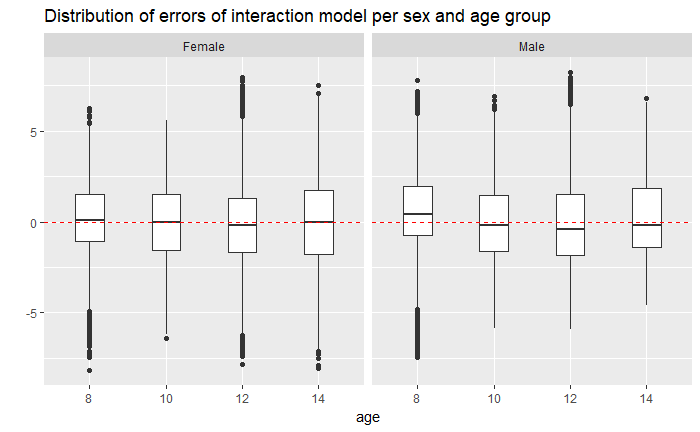

```r
beta <- t(res15$beta)
err <- y - X2 %*% beta
pltdata <- data.frame(mean_err = err, age = ordered(dental$age), sex = dental$Sex)
pltdata <- pltdata %>%
  gather(subject, error, -c(age, sex))
ggplot(pltdata, aes(age, error)) +
  geom_boxplot() +
  geom_hline(aes(yintercept = 0), colour = "red", linetype = "dashed") +
  facet_grid(. ~ sex) +
  ylab("") +
  ggtitle(paste("Distribution of errors of interaction model per sex and age group"))
```

With the new model we are doing a better modelling of the errors independent of sex or age, although it seems we have bigger residuals.

Back to Index